# Final Exam

## Set 2

For this problem, we will use a cleaned-up version of the dataset of Michael Ross, “Does Oil Hinder Democracy?” *World Politics*, 2001.That paper estimated a time series cross-section model of Polity scores regressed on oil exports and a battery of controls. In this problem, we will focus on a single cross-section, and instead focus on model fitting.

Load and pre-process this data using the following code:

```r
library(dplyr)
rossoil <- read.csv("https://raw.githubusercontent.com/vcoxon/Final/master/input/rossoildata.csv") %>%
   arrange(id1, year) %>%
   group_by(id1) %>%
   mutate(oilL5 = lag(wdr123, 5) / 100,
          metalL5 = lag(wdr313, 5) / 100,
          GDPpcL5 = lag(wdr135, 5) / 100,
          islam = islam / 100) %>%
   filter(year == 1990) %>%
   select(regime1, oilL5, metalL5, GDPpcL5, islam, oecd, cty_name, id, id1) %>%
   na.omit() %>%
   ungroup()
```

The variables are:

| Variable | Description |
| --- | --- |
| `regime1` | 1–10 scale increasing in democracy; computed from Polity components |
| `oilL5` | Fuel exports as a proportion of GDP, lagged 5 years |
| `metalL5` | Ore and mineral exports as a proportion of GDP, lagged 5 years |
| `GDPpcL5` | per capita GDP in PPP dollars, lagged 5 years |
| `islam` | Muslims as a proportion of population, 1970 data |
| `oecd` | Dummy for rich industrialized countries |
| `cty_name` | The name of the country observed |
| `id` | A three character abbreviation of the country name |
| `id1` | A numeric country code |

11. (4 points) Estimate a linear regression of `regime1` on `oilL5`, `metalL5`, `GDPpcL5`, `islam`, and `oecd`.

```r
model1 <- lm(formula = regime1 ~ oilL5 + metalL5 + GDPpcL5 + islam + oecd, data = rossoil)
summary(model1)
```

```
##
## Call:
## lm(formula = regime1 ~ oilL5 + metalL5 + GDPpcL5 + islam + oecd,
##     data = rossoil)
##
## Residuals:
##    Min     1Q Median     3Q    Max
## -6.149 -1.060  0.240  1.626  6.410
##
## Coefficients:
##              Estimate Std. Error t value Pr(>|t|)
## (Intercept)  7.317093   0.601604  12.163  < 2e-16 ***
## oilL5       -2.248033   1.188721  -1.891   0.0631 .
## metalL5     -0.072321   3.071137  -0.024   0.9813
## GDPpcL5      0.009047   0.010878   0.832   0.4087
## islam       -4.441526   1.028442  -4.319 5.57e-05 ***
## oecd         1.844710   1.213382   1.520   0.1334
## ---
## Signif. codes:  0 '***' 0.001 '**' 0.01 '*' 0.05 '.' 0.1 ' ' 1
##
## Residual standard error: 2.626 on 64 degrees of freedom
## Multiple R-squared:  0.5093, Adjusted R-squared:  0.471
## F-statistic: 13.29 on 5 and 64 DF,  p-value: 6.978e-09
```

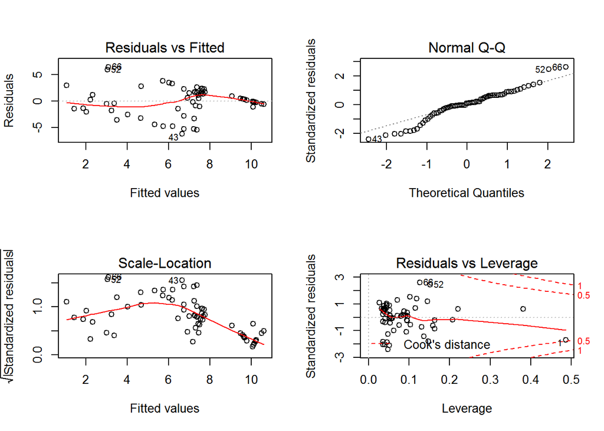

```r
par(mfrow = c(2,2))
plot(model1)
```

12. (8 points) Provide a substantive interpretation of each coefficient and note whether a given coefficient is statistically significant. *Since several of the explanatory variables are lagged, the linear coefficients can most easily be interpreted and understood by realizing that the estimated coefficient of a lagged $\X$ measures the change in this year’s $\Y$ atributed to a one unit increase in the $\X$* **five years ago**, *holding all other variables constant.*

*For instance, the equation would look like this:*  
$\Regime1 = \beta_{0} + \beta_{1}*'oilL5' + \beta_{2}*'metalL5' + \beta_{3}*'GDPpcL5' + \beta_{4}*'islam' + \beta_{5}*'oecd'$

*The country’s regime score is affected by the following variables:*

*1. Each one unit increase in ‘oilL5’ (fuel exports as a proportion of GDP) 5 years ago decreases the computed democracy score ‘regime1’ by approximately 2.25 units, holding all other variables constant. This variable is statistically signficant at the $\alpha_{0.10}$ level as $\p = 0.0631$ in this model.*  
*2. Each one unit increase in ‘metalL5’ (ore & mineral exports as a proprotion of GDP) 5 years ago decreases the computed democracy score ‘regime1’ by appproximately 0.07 units, holding all other variables constant. This variable is not statistically significant in this model.*  
*3. Each one unit increase in ‘GDPpcL5’ (per capita GDP in PPP dollars) 5 years ago increases the computed democracy score ‘regime1’ by approximately 0.01, holding all other variables constant. This variable is not statistically siignificant in this model.*  
*4. Each one unit increase in ‘islam’ (Muslims as a prportion of population) decreases the computed democracy score ‘regime1’ by approximately 4.44 units, holding all other variables constant. This variable statisticaly signficant at the $\alpha_{0.001}$ level as $\p = 5.57e-05$ in this model.*  
*5. When countries are OECD countries, the computed democracy score ‘regime1’ increases by approximately 1.84 units, holding all other variables constant. This variable is not statistically significant in this model.*

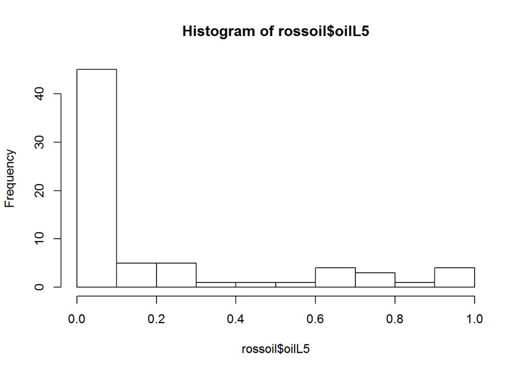

```r
hist(rossoil$oilL5)
```

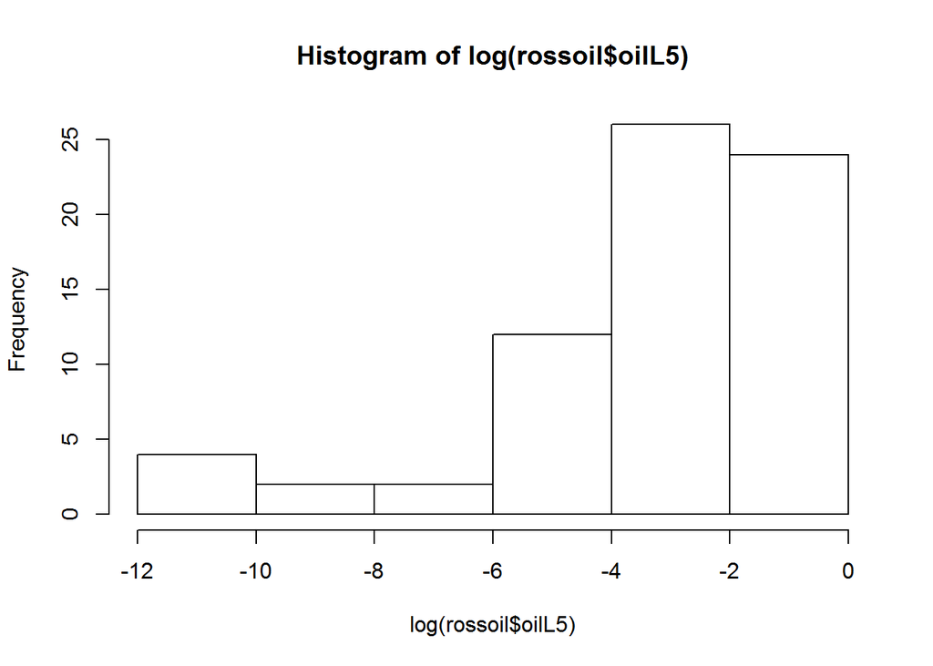

```r
hist(log(rossoil$oilL5))
```

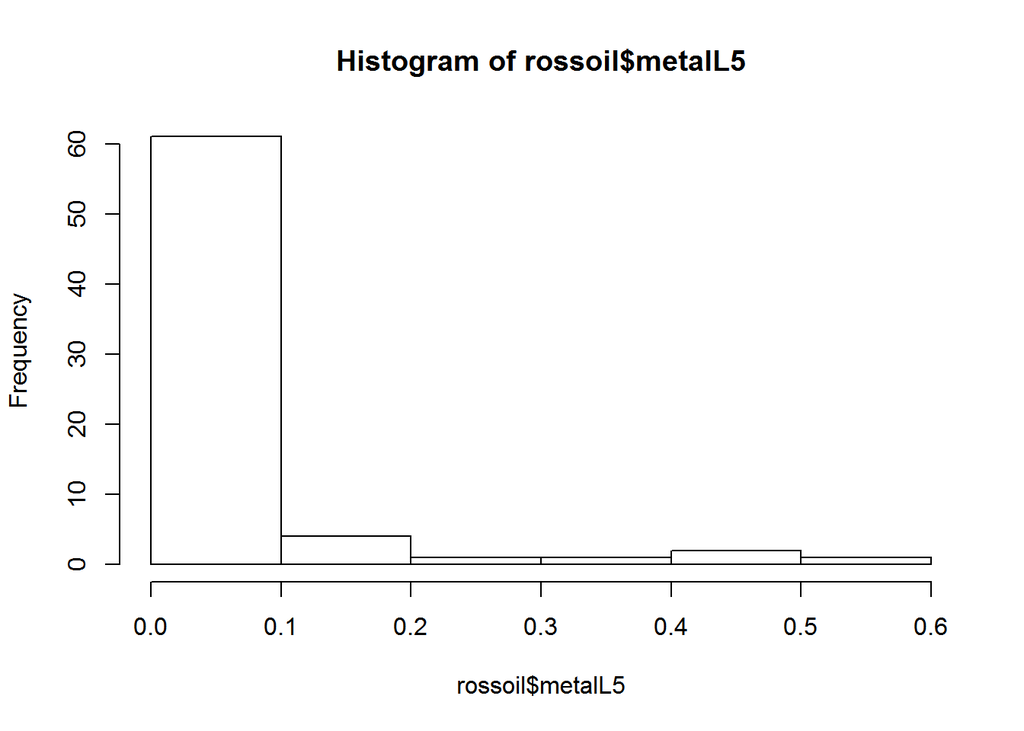

```r
hist(rossoil$metalL5)
```

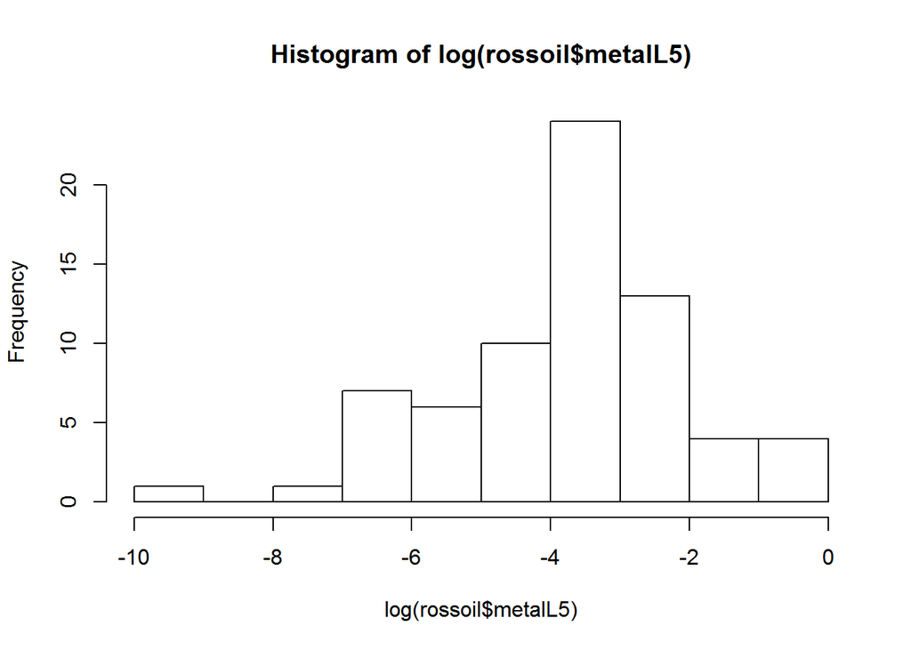

```r
hist(log(rossoil$metalL5))
```

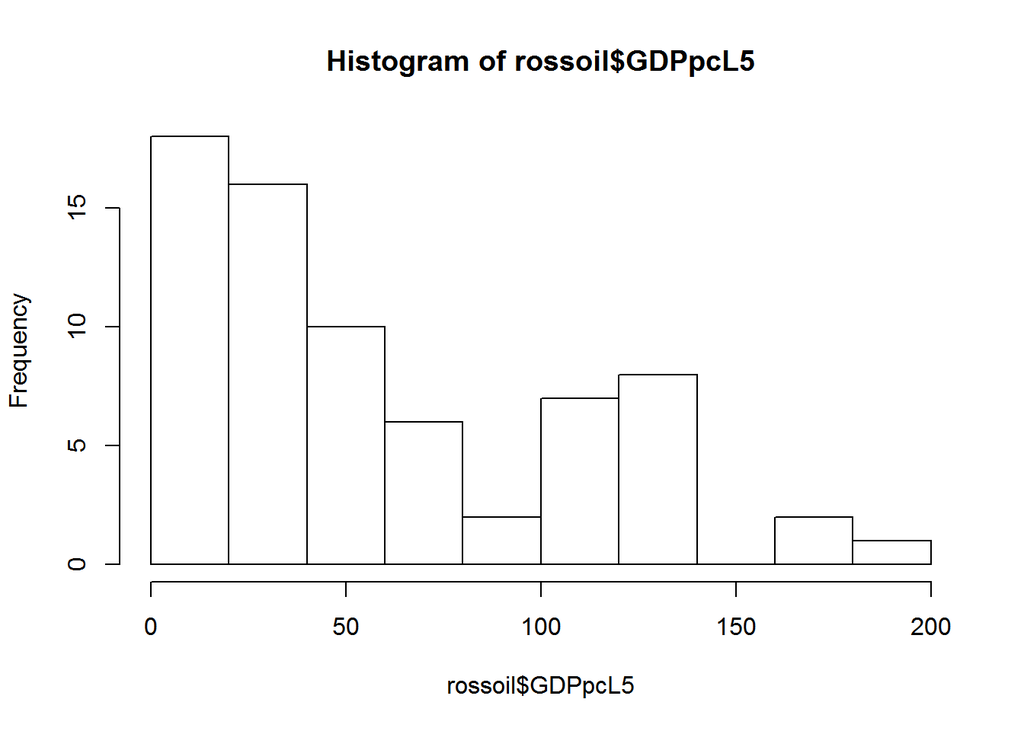

```r
hist(rossoil$GDPpcL5)
```

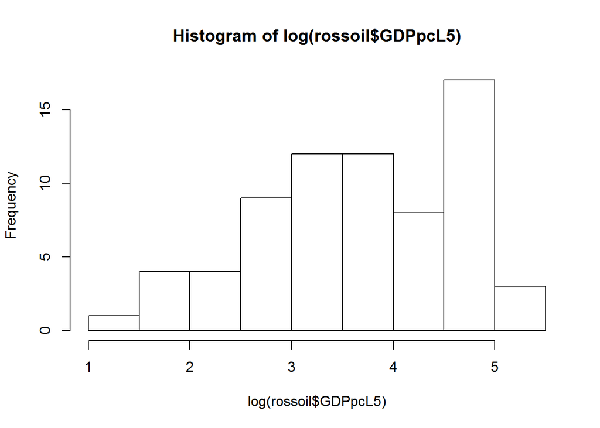

```r
hist(log(rossoil$GDPpcL5))
```

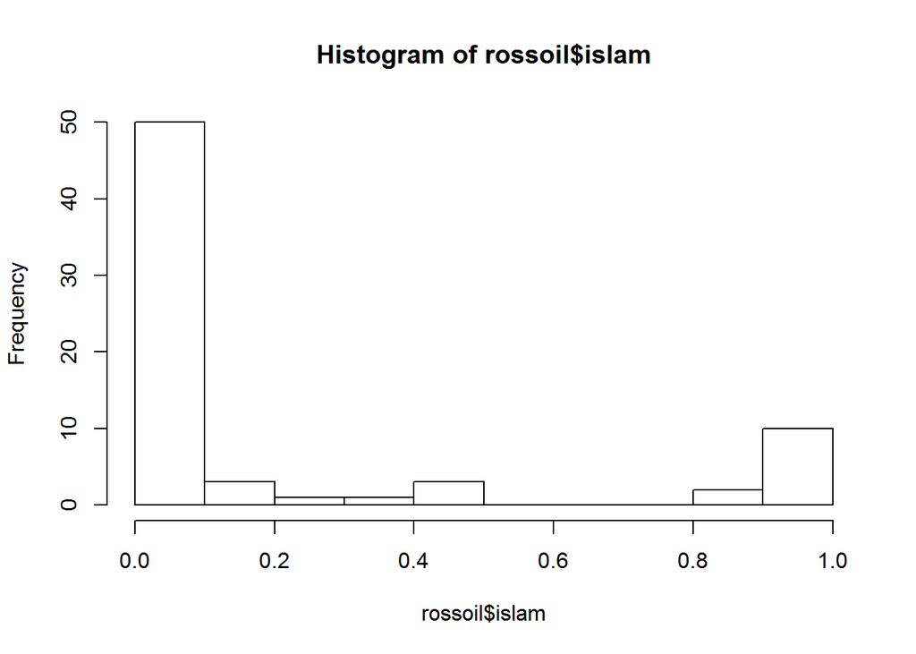

```r
hist(rossoil$islam)
```

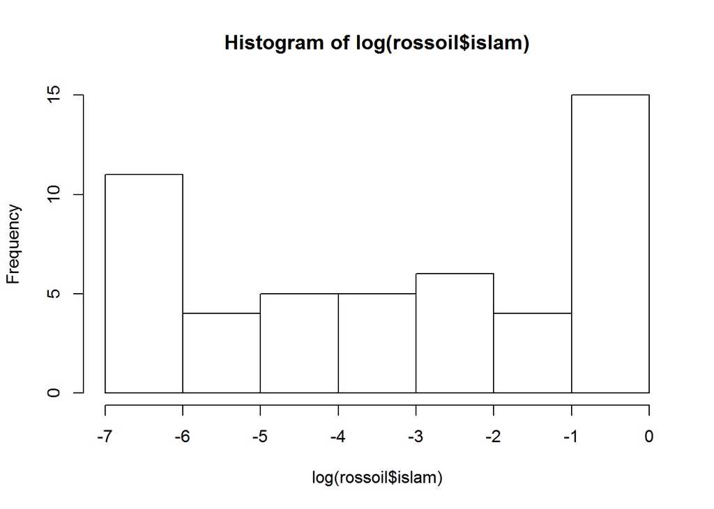

```r
hist(log(rossoil$islam))
```

*I have concerns that this model may not be the best fit; several of the variables are not normally distributed (may need log transformation) and Cook’s Distance demonstrates that there are some high leverage points that appear to (possibly) affect the slope of fitted regression line.*

13. (4 points) Calculate the expected change in `regime1` given a change in `oilL5` from the 50th percentile to the 95th percentile of the fully observed data, all else equal.

```r
oil_lo <- mean(rossoil$oilL5)
oil_hi <- mean(rossoil$oilL5) + 2*sd(rossoil$oilL5)

pred1_oil_lo <- predict(model1,newdata = data.frame(oilL5 = oil_lo, metalL5 = mean(rossoil$metalL5), GDPpcL5 = mean(rossoil$GDPpcL5), islam = mean(rossoil$islam), oecd = 0), interval = "confidence")

pred1_oil_hi <- predict(model1,newdata = data.frame(oilL5 = oil_hi, metalL5 = mean(rossoil$metalL5), GDPpcL5 = mean(rossoil$GDPpcL5), islam = mean(rossoil$islam), oecd = 0), interval = "confidence")

pred1_diff <- data.frame(diff = pred1_oil_hi[ , "fit"] - pred1_oil_lo[ , "fit"])
head(pred1_diff)
```

```
##        diff
## 1 -1.332075
```

14. (8 points) Using the residuals from the regression in above, create the following diagnostic plots:

```r
summary(model1)
```

```
##
## Call:
## lm(formula = regime1 ~ oilL5 + metalL5 + GDPpcL5 + islam + oecd,
##     data = rossoil)
##
## Residuals:
##    Min     1Q Median     3Q    Max
## -6.149 -1.060  0.240  1.626  6.410
##
## Coefficients:
##              Estimate Std. Error t value Pr(>|t|)
## (Intercept)  7.317093   0.601604  12.163  < 2e-16 ***
## oilL5       -2.248033   1.188721  -1.891   0.0631 .
## metalL5     -0.072321   3.071137  -0.024   0.9813
## GDPpcL5      0.009047   0.010878   0.832   0.4087
## islam       -4.441526   1.028442  -4.319 5.57e-05 ***
## oecd         1.844710   1.213382   1.520   0.1334
## ---
## Signif. codes:  0 '***' 0.001 '**' 0.01 '*' 0.05 '.' 0.1 ' ' 1
##
## Residual standard error: 2.626 on 64 degrees of freedom
## Multiple R-squared:  0.5093, Adjusted R-squared:  0.471
## F-statistic: 13.29 on 5 and 64 DF,  p-value: 6.978e-09
```

```
- Plot the standardized residuals against the fitted values
```

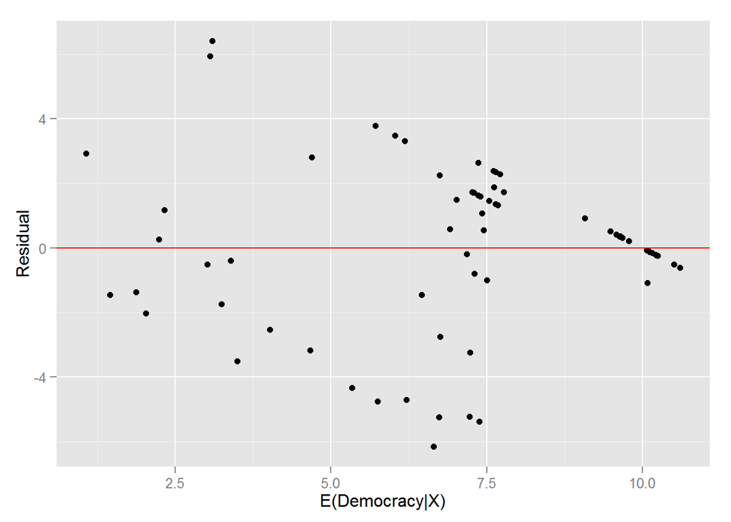

```r
result.vals <- data.frame(residuals = model1$residuals, fitted = model1$fitted.values , outcome = rossoil$regime1, std.resids = rstandard(model1))

ggplot(result.vals, aes(x = fitted, y = residuals)) + geom_point() + geom_hline(yintercept = 0, colour = "red") + ylab('Residual') + xlab('E(Democracy|X)')
```

```
## geom_smooth: method="auto" and size of largest group is <1000, so using loess. Use 'method = x' to change the smoothing method.
```

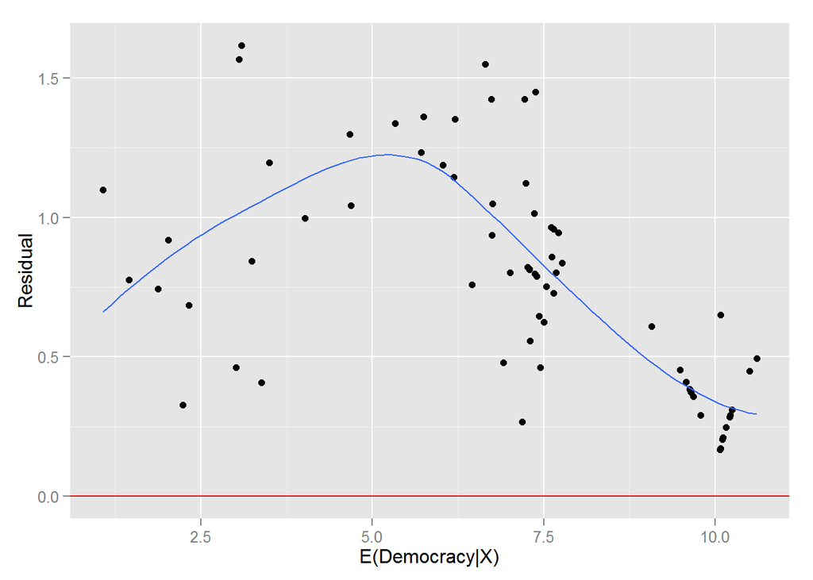

[output not shown]

```r
ggplot(result.vals, aes(x = fitted, y = sqrt(abs(std.resids)))) + geom_point() + geom_hline(yintercept = 0, colour = "red") + geom_smooth(se = FALSE) + ylab('Residual') + xlab('E(Democracy|X)')
```

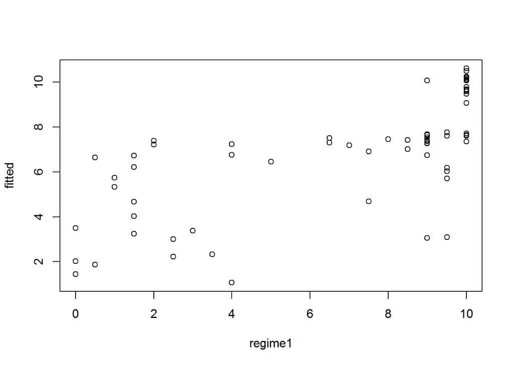

```r
results = data.frame(residuals = model1$residuals, fitted = model1$fitted.values, std.resids = rstandard(model1), rossoil)
par(mfrow = c(1,1))
plot(fitted ~ regime1, results)
```

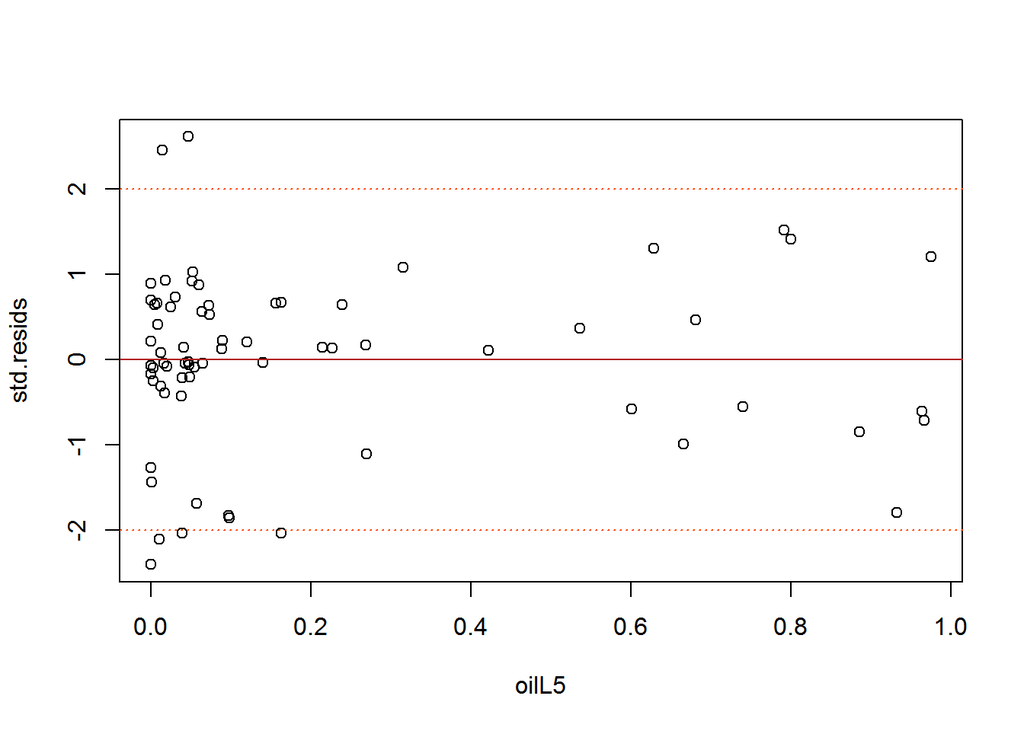

```r
plot(std.resids ~ oilL5, results)
abline(h = 2, lty = 3, col = 'orangered'); abline(h = -2, lty = 3, col = 'orangered'); abline(h = 0, lty = 1, col = 'firebrick')
```

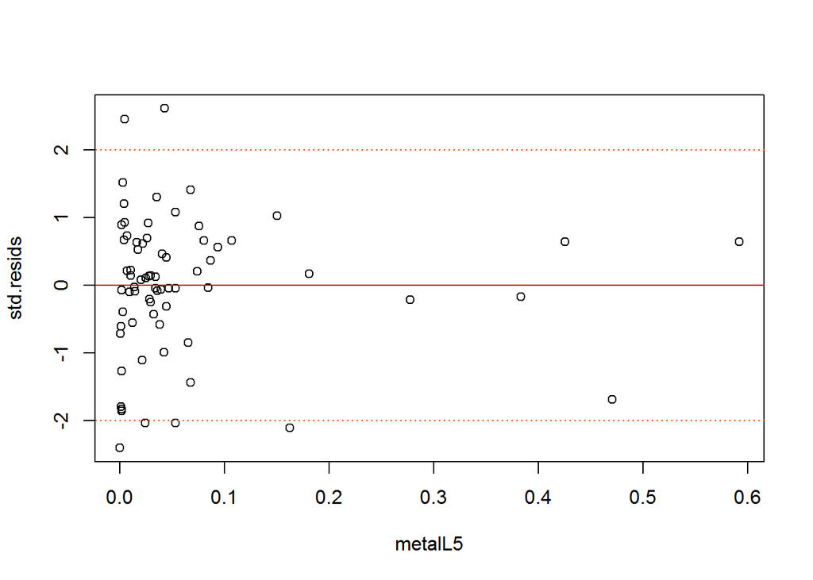

```r
plot(std.resids ~ metalL5, results)
abline(h = 2, lty = 3, col = 'orangered'); abline(h = -2, lty = 3, col = 'orangered'); abline(h = 0, lty = 1, col = 'firebrick')
```

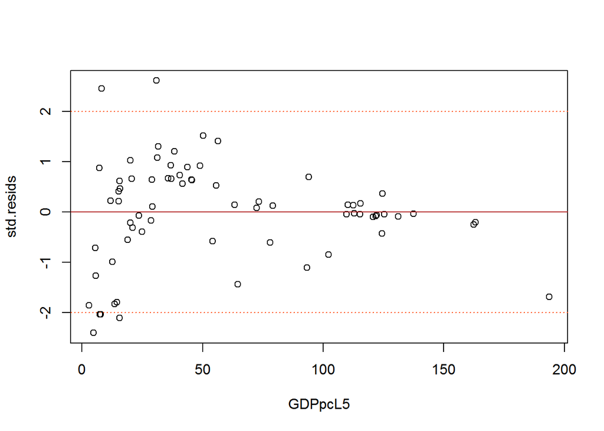

```r
plot(std.resids ~ GDPpcL5, results)
abline(h = 2, lty = 3, col = 'orangered'); abline(h = -2, lty = 3, col = 'orangered'); abline(h = 0, lty = 1, col = 'firebrick')
```

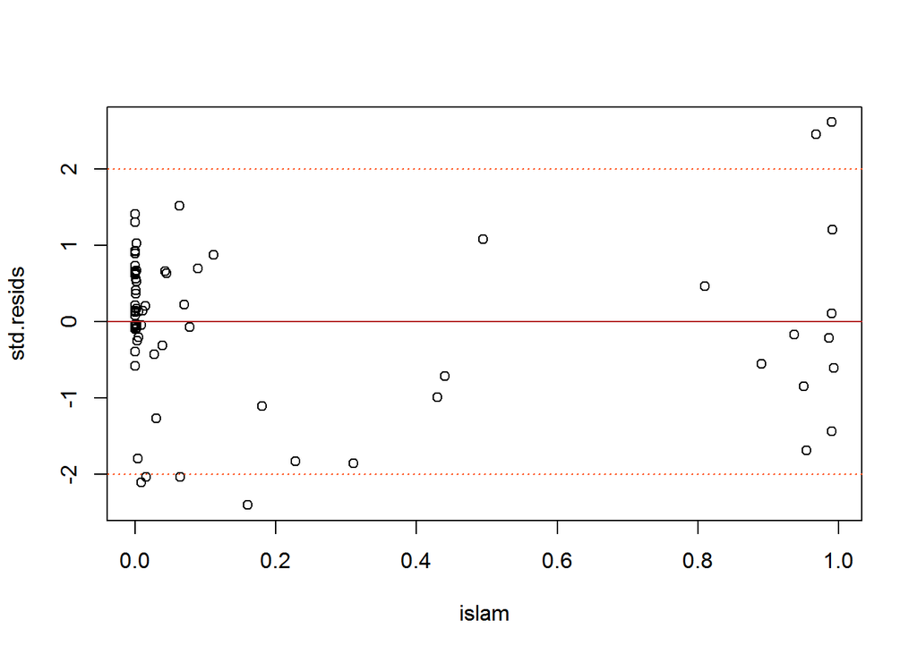

```r
plot(std.resids ~ islam, results)
abline(h = 2, lty = 3, col = 'orangered'); abline(h = -2, lty = 3, col = 'orangered'); abline(h = 0, lty = 1, col = 'firebrick')
```

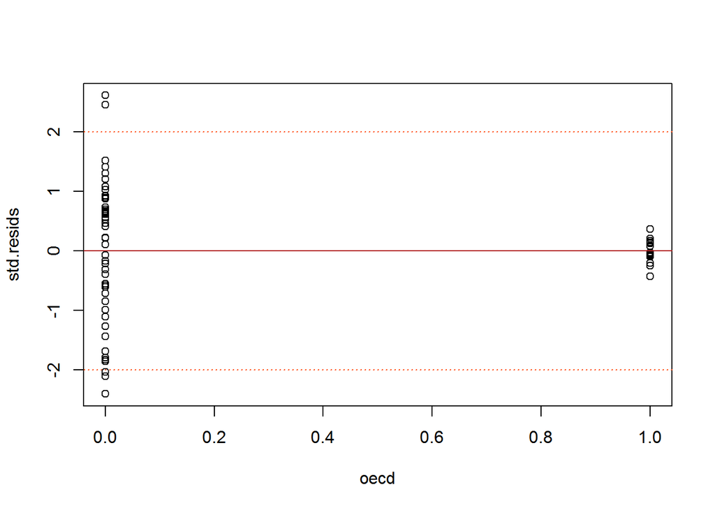

```r
plot(std.resids ~ oecd, results)
abline(h = 2, lty = 3, col = 'orangered'); abline(h = -2, lty = 3, col = 'orangered'); abline(h = 0, lty = 1, col = 'firebrick')
```

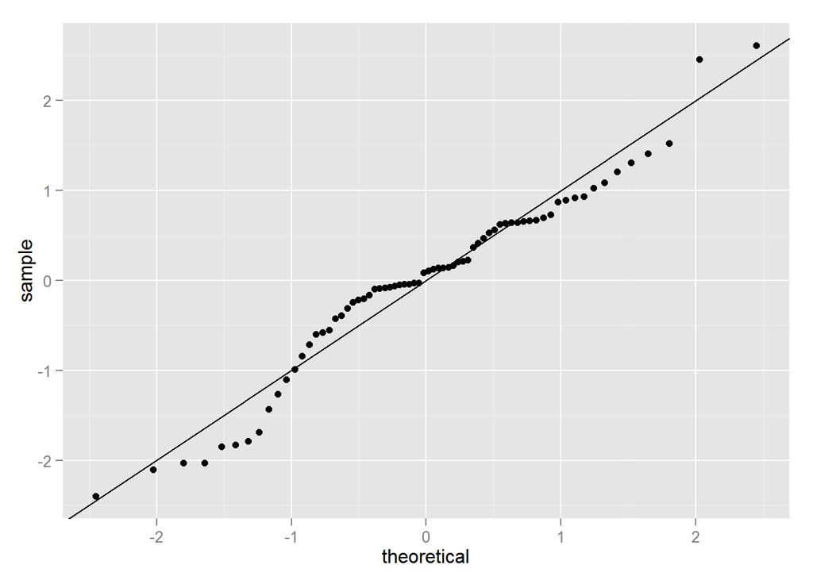

```r
#Check for normality of errors...
ggplot(results, aes(sample = std.resids)) + stat_qq() + geom_abline(slope = 1)
```

```r
par(mfrow = c(2,2))
```

```
- Plot $Y$ versus $\hat{Y}$
```

```
## geom_smooth: method="auto" and size of largest group is <1000, so using loess. Use 'method = x' to change the smoothing method.
```

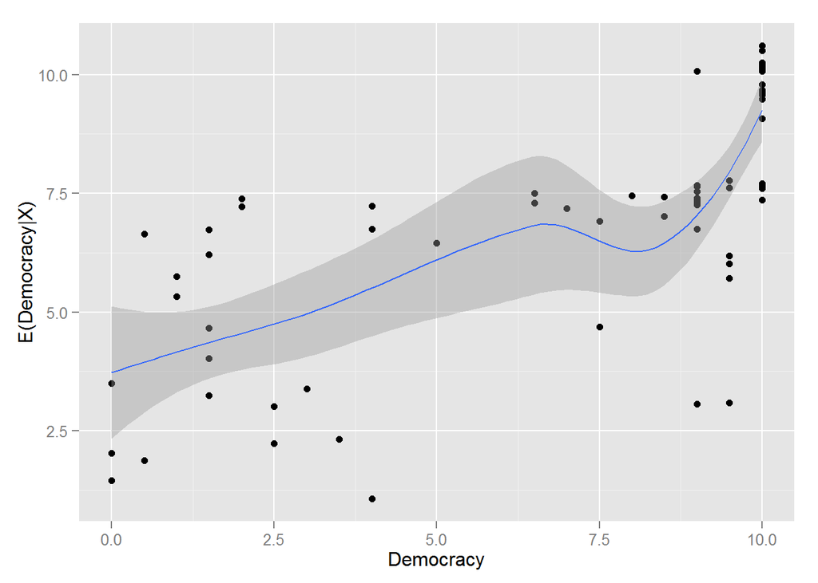

```r
ggplot(result.vals, aes(y = fitted, x = outcome)) + geom_point() + geom_smooth() + ylab('E(Democracy|X)') + xlab('Democracy')
```

15. (6 points) What do these diagnostics tell you about the presence of heteroskedasticity, specification error, and outliers?

16. (4 points) Rerun the regression using any 2 non-linear transformations for any of the covariates (“x variables”) based upon your theoretical expectations and/or your diagnostics above). You’re welcome to explore several specifications, but only present the specification that you think is best and describe why you choose to transform what you did. You WILL NOT be graded on whether the model is ultimately a good fitting model.

```r
summary(rossoil$islam)
```

```
##    Min. 1st Qu.  Median    Mean 3rd Qu.    Max.
##  0.0000  0.0000  0.0070  0.2064  0.1750  0.9930
```

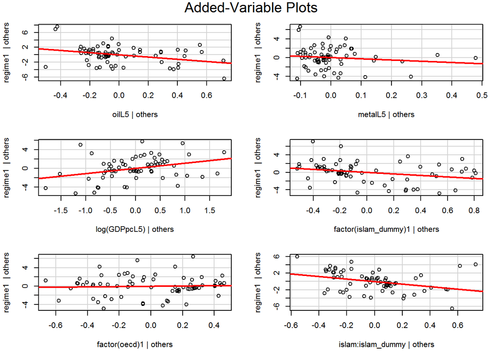

```r
rossoil$islam_dummy = ifelse(rossoil$islam>='0.0070',1,0)
#rossoil$oil_mod <- log(rossoil$oilL5+ 0.001)

#model4 <- lm(formula = regime1 ~ oil_mod + metalL5 + log(GDPpcL5) + factor(islam_dummy) + islam:islam_dummy + factor(oecd), data = rossoil)
#avPlots(model4)
#summary(model4)
#plot(model4)

model5 <- lm(formula = regime1 ~ oilL5 + metalL5 + log(GDPpcL5) + factor(islam_dummy) + islam:islam_dummy + factor(oecd), data = rossoil)
avPlots(model5)
```

```r
summary(model5)
```

```
##
## Call:
## lm(formula = regime1 ~ oilL5 + metalL5 + log(GDPpcL5) + factor(islam_dummy) +
##     islam:islam_dummy + factor(oecd), data = rossoil)
##
## Residuals:
##     Min      1Q  Median      3Q     Max
## -4.7953 -1.0332  0.0218  1.2226  6.3530
##
## Coefficients:
##                      Estimate Std. Error t value Pr(>|t|)
## (Intercept)            5.0456     1.4483   3.484 0.000905 ***
## oilL5                 -2.9497     1.0729  -2.749 0.007781 **
## metalL5               -2.6134     2.7459  -0.952 0.344866
## log(GDPpcL5)           1.1346     0.4134   2.745 0.007883 **
## factor(islam_dummy)1  -1.7502     0.7510  -2.330 0.022996 *
## factor(oecd)1          0.3305     0.9392   0.352 0.726098
## islam:islam_dummy     -3.0803     1.0945  -2.814 0.006516 **
## ---
## Signif. codes:  0 '***' 0.001 '**' 0.01 '*' 0.05 '.' 0.1 ' ' 1
##
## Residual standard error: 2.345 on 63 degrees of freedom
## Multiple R-squared:  0.615,  Adjusted R-squared:  0.5783
## F-statistic: 16.77 on 6 and 63 DF,  p-value: 1.876e-11
```

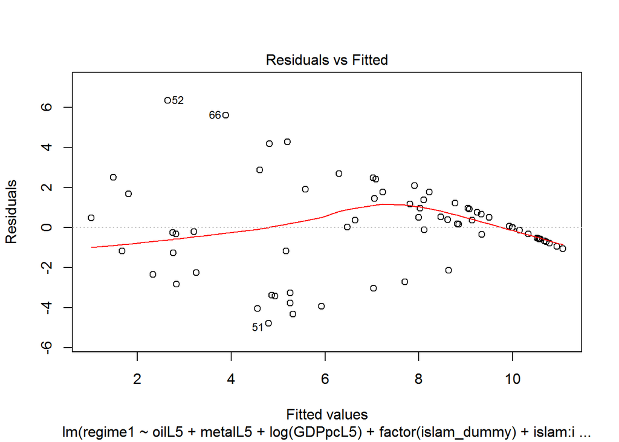

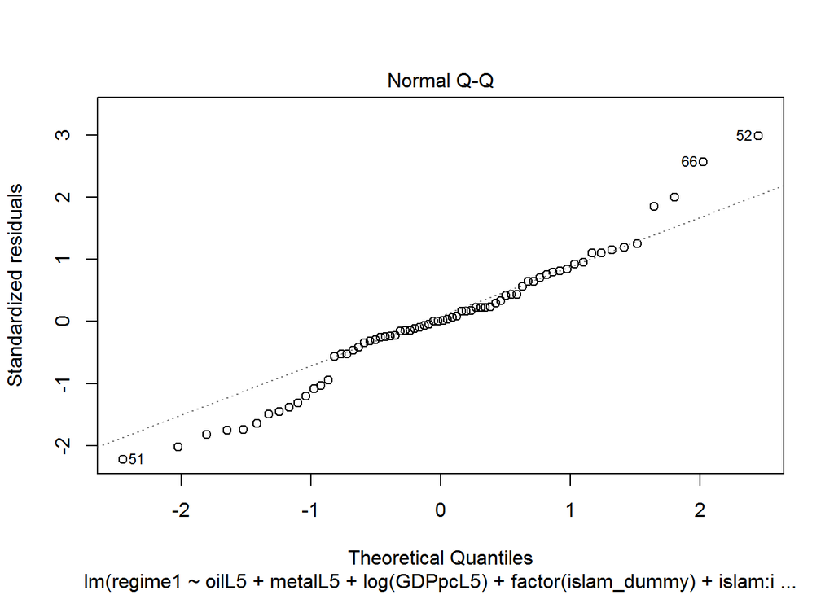

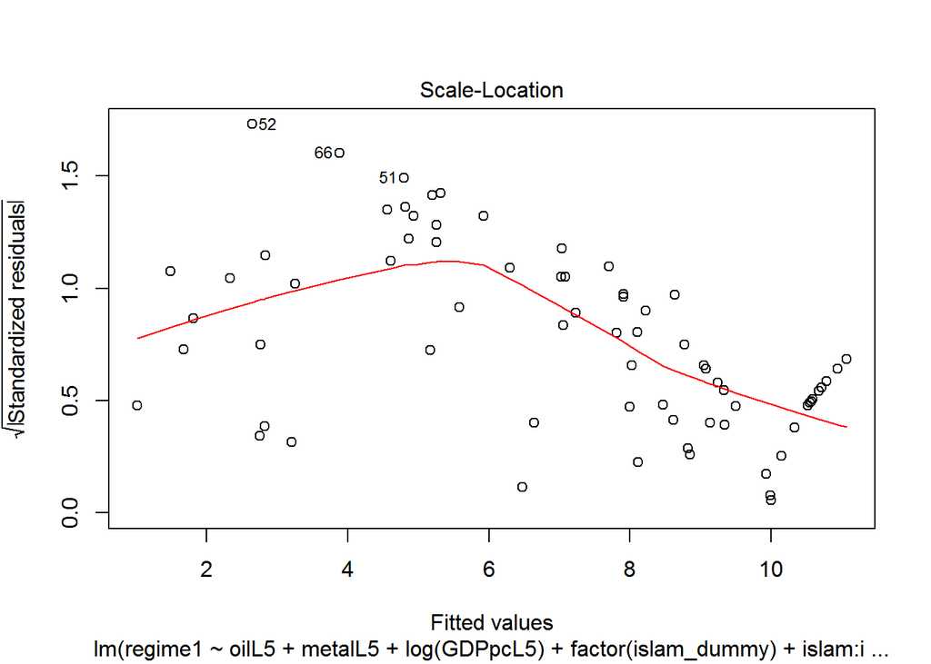

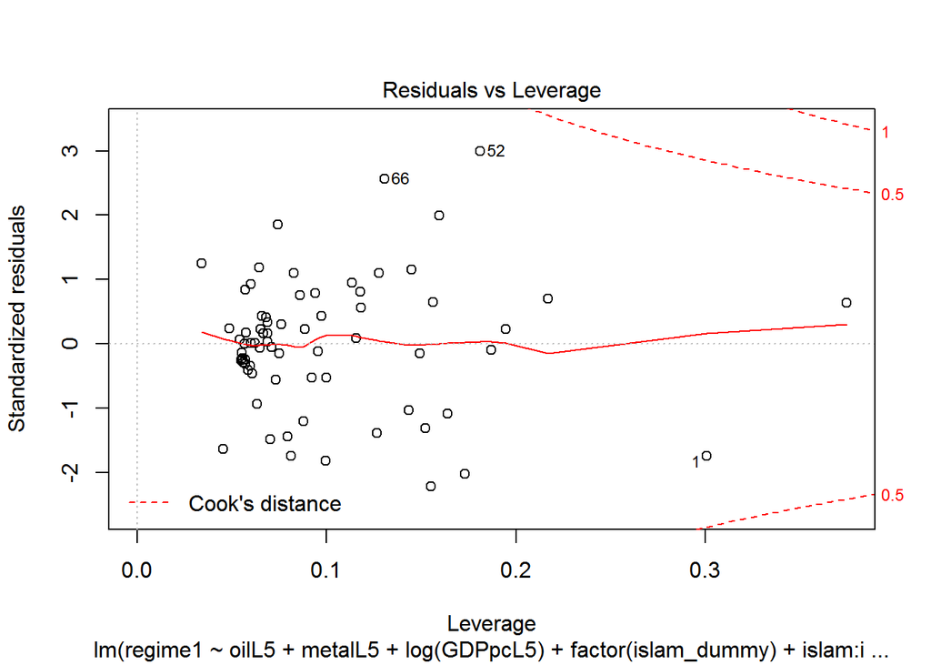

```r
plot(model5)
```

```r
#library(texreg)
#screenreg(list(model1, model4, model5))
```

*Based on the histograms discussed in #12, I could have log transformed several variables to better address deal the right skew in the variable. I chose to create a model (model5) that log transformed ‘GDPpcL5’ while also creating a dummy variable for the values of ‘islam’ above the median of 0.0070. I chose to use the median values of ‘islam’ as a cut point to correct for the effects of high value observations on the ‘islam’ mean.*

17. (4 points) For your new model, record and compare the adjusted $R^2$, AIC score, and BIC score for your new model.

```r
library(stargazer); library(knitr)
stargazer(model1, model5, type = 'text', column.labels = c('Model1', 'Model 5'), model.names = FALSE, model.numbers = FALSE)
```

```
##
## ==================================================================
##                                   Dependent variable:
##                      ---------------------------------------------
##                                         regime1
##                              Model1                Model 5
## ------------------------------------------------------------------
## oilL5                       -2.248*               -2.950***
##                             (1.189)                (1.073)
##
## metalL5                      -0.072                 -2.613
##                             (3.071)                (2.746)
##
## GDPpcL5                      0.009
##                             (0.011)
##
## islam                      -4.442***
##                             (1.028)
##
## oecd                         1.845
##                             (1.213)
##
## log(GDPpcL5)                                       1.135***
##                                                    (0.413)
##
## factor(islam_dummy)1                               -1.750**
##                                                    (0.751)
##
## factor(oecd)1                                       0.330
##                                                    (0.939)
##
## islam:islam_dummy                                 -3.080***
##                                                    (1.095)
##
## Constant                    7.317***               5.046***
##                             (0.602)                (1.448)
##
## ------------------------------------------------------------------
## Observations                   70                     70
## R2                           0.509                  0.615
## Adjusted R2                  0.471                  0.578
## Residual Std. Error     2.626 (df = 64)        2.345 (df = 63)
## F Statistic          13.287*** (df = 5; 64) 16.771*** (df = 6; 63)
## ==================================================================
## Note:                                  *p<0.1; **p<0.05; ***p<0.01
```

```r
AIC(model1,model5)
```

```
##        df      AIC
## model1  7 341.5458
## model5  8 326.5733
```

```r
BIC(model1,model5)
```

```
##        df      BIC
## model1  7 357.2853
## model5  8 344.5613
```

18. (4 points) For both of your new specifications, compute the expected change in `regime1` given a change in `oilL5` from the 50th percentile to the 95th percentile of the fully observed data.

```r
#Model4
#oil_lo_4 <- mean(rossoil$oil_mod)
#oil_hi_4 <- mean(rossoil$oil_mod) + 2*sd(rossoil$oil_mod)

#pred4_oil_lo <- predict(model4,newdata = data.frame(oil_mod = oil_lo_4, metalL5 = mean(rossoil$metalL5), GDPpcL5 = mean(log(rossoil$GDPpcL5)), islam_dummy = 0, islam = median(rossoil$islam), oecd = 0), interval = "confidence")

#pred4_oil_hi <- predict(model4,newdata = data.frame(oil_mod = oil_hi_4, metalL5 = mean(rossoil$metalL5), GDPpcL5 = mean(log(rossoil$GDPpcL5)), islam_dummy = 0, islam = median(rossoil$islam), oecd = 0), interval = "confidence")

#pred4_diff <- data.frame(diff = pred4_oil_hi[ , "fit"] - pred4_oil_lo[ , "fit"])
#head(pred4_diff)

#Model5
mean(rossoil$GDPpcL5)
```

```
## [1] 58.03571
```

```r
oil_lo_5 <- mean(rossoil$oilL5)
oil_hi_5 <- mean(rossoil$oilL5) + 2*sd(rossoil$oilL5)

pred5_oil_lo <- predict(model5,newdata = data.frame(oilL5 = oil_lo_5, metalL5 = mean(rossoil$metalL5), GDPpcL5 = mean(rossoil$GDPpcL5), islam_dummy = 0, islam = median(rossoil$islam), oecd = 0), interval = "confidence")

pred5_oil_hi <- predict(model5,newdata = data.frame(oilL5 = oil_hi, metalL5 = mean(rossoil$metalL5), GDPpcL5 = mean(rossoil$GDPpcL5), islam_dummy = 0, islam = median(rossoil$islam), oecd = 0), interval = "confidence")

pred5_diff <- data.frame(diff = pred5_oil_hi[ , "fit"] - pred5_oil_lo[ , "fit"])
head(pred5_diff)
```

```
##        diff
## 1 -1.747859
```

19. (4 points) Assess how much substantive difference finding the best model makes. Be specific and concrete; i.e., show what each model does.

```r
par(mfrow = c(1,1))

L1 <- prod(dnorm(model1$residuals, mean = 0, sd = summary(model1)$sigma))
#L2 <- prod(dnorm(model4$residuals, mean = 0, sd = summary(model4)$sigma))
L3 <- prod(dnorm(model5$residuals, mean = 0, sd = summary(model5)$sigma))
c(L1, L3)
```

```
## [1] 6.532544e-72 3.008676e-68
```

```r
stargazer(model1,model5, type = 'text', column.labels = c('Model1', 'Model 5'), model.names = FALSE, model.numbers = FALSE)
```

```
##
## ==================================================================
##                                   Dependent variable:
##                      ---------------------------------------------
##                                         regime1
##                              Model1                Model 5
## ------------------------------------------------------------------
## oilL5                       -2.248*               -2.950***
##                             (1.189)                (1.073)
##
## metalL5                      -0.072                 -2.613
##                             (3.071)                (2.746)
##
## GDPpcL5                      0.009
##                             (0.011)
##
## islam                      -4.442***
##                             (1.028)
##
## oecd                         1.845
##                             (1.213)
##
## log(GDPpcL5)                                       1.135***
##                                                    (0.413)
##
## factor(islam_dummy)1                               -1.750**
##                                                    (0.751)
##
## factor(oecd)1                                       0.330
##                                                    (0.939)
##
## islam:islam_dummy                                 -3.080***
##                                                    (1.095)
##
## Constant                    7.317***               5.046***
##                             (0.602)                (1.448)
##
## ------------------------------------------------------------------
## Observations                   70                     70
## R2                           0.509                  0.615
## Adjusted R2                  0.471                  0.578
## Residual Std. Error     2.626 (df = 64)        2.345 (df = 63)
## F Statistic          13.287*** (df = 5; 64) 16.771*** (df = 6; 63)
## ==================================================================
## Note:                                  *p<0.1; **p<0.05; ***p<0.01
```

```r
AIC(model1,model5)
```

```
##        df      AIC
## model1  7 341.5458
## model5  8 326.5733
```

```r
BIC(model1,model5)
```

```
##        df      BIC
## model1  7 357.2853
## model5  8 344.5613
```

*After conducting a comparison of the models and their corresponding AIC and BIC scores it appears that Model 5 seems to best balance parsimony and description with an R-square value that acccounts for 61.5% of variation in the outcome ‘regime1’. Model 5 may need some non-linear transformation tweaking to become more descriptive, but I believe it may be pointing in the right direction. Model 5 also has the most significant F statistic at 16.771*** (df = 6,63); **of the models** evaluated, in addition to having the lowest Residual Standard Errors.*

20. (4 points) What other problems in the specification or estimation method remain unaddressed by our efforts (no more than 2-3 sentences)?

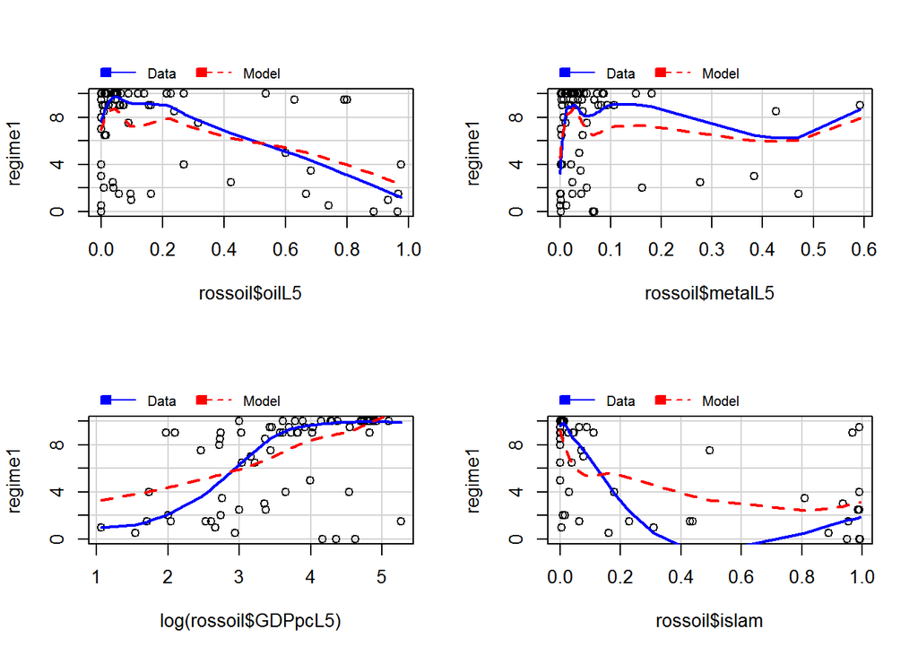

```r
par(mfrow = c(2,2))
library(car)
#mmp(model4, rossoil$oil_mod)
#mmp(model4, rossoil$metalL5)
#mmp(model4, log(rossoil$GDPpcL5))
#mmp(model4, rossoil$islam)
#mmp(model4, rossoil$oecd)
#mmp(model4, rossoil$islam_dummy)

mmp(model5, rossoil$oilL5)
mmp(model5, rossoil$metalL5)
mmp(model5, log(rossoil$GDPpcL5))
mmp(model5, rossoil$islam)
```

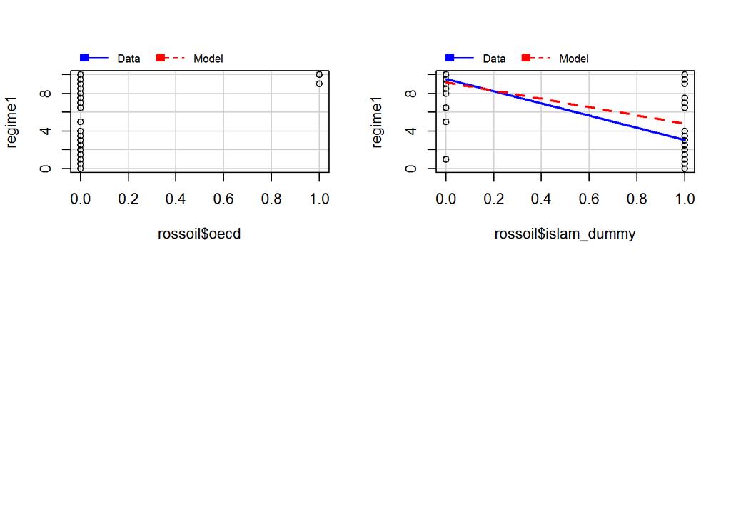

```r
mmp(model5, rossoil$oecd)
mmp(model5, rossoil$islam_dummy)
```

*Model 5 does a decent job of describing the data, but I don’t think I need to log transform ‘GDPpcL5’. Where my model appears to fail is in the specification of the relationship of ‘islam’ to the outcome. The dummy variable helps, but I need to transform ‘islam’ in a way that better expresses the relationship of this variable to the ouctome, possibly by changing the dummy to ‘mean(islam)’. I have continuing concerns regarding the best model specification to use with this data, particularly because the models do not do a better job accounting for the variation in the outcome (it only seems to account for a little more than half; this seems somewhat no better than chance). I think we might be missing some important explanatory variables that could be included in the model like women’s rights which could be a proxy measure of oppression, or possibly a corruption index.* **Please see NOTES at end of document.**

21. Try a new specification that alters the dependent variable in order to address the heteroskedasticity problem. Assess whether your new model successfully addresses the problem.

```r
rossoil$regime2 = rossoil$regime1^2
Model6 <- lm(regime2 ~ oilL5 + metalL5 + GDPpcL5 + factor(islam_dummy) + islam:islam_dummy +  I(islam ^ 2) + factor(oecd), data = rossoil)
summary(Model6)
```

```
##
## Call:
## lm(formula = regime2 ~ oilL5 + metalL5 + GDPpcL5 + factor(islam_dummy) +
##     islam:islam_dummy + I(islam^2) + factor(oecd), data = rossoil)
##
## Residuals:
##     Min      1Q  Median      3Q     Max
## -55.470 -11.840  -1.795  14.962  60.786
##
## Coefficients:
##                        Estimate Std. Error t value Pr(>|t|)
## (Intercept)            76.52683    7.39236  10.352 3.85e-15 ***
## oilL5                 -22.59083   12.26443  -1.842   0.0703 .
## metalL5               -24.90527   31.09235  -0.801   0.4262
## GDPpcL5                 0.07196    0.11049   0.651   0.5173
## factor(islam_dummy)1  -20.69972    9.34503  -2.215   0.0304 *
## I(islam^2)             94.05950   63.43547   1.483   0.1432
## factor(oecd)1          22.16879   12.17454   1.821   0.0734 .
## islam:islam_dummy    -119.83646   66.12535  -1.812   0.0748 .
## ---
## Signif. codes:  0 '***' 0.001 '**' 0.01 '*' 0.05 '.' 0.1 ' ' 1
##
## Residual standard error: 26.28 on 62 degrees of freedom
## Multiple R-squared:  0.623,  Adjusted R-squared:  0.5804
## F-statistic: 14.63 on 7 and 62 DF,  p-value: 4.371e-11
```

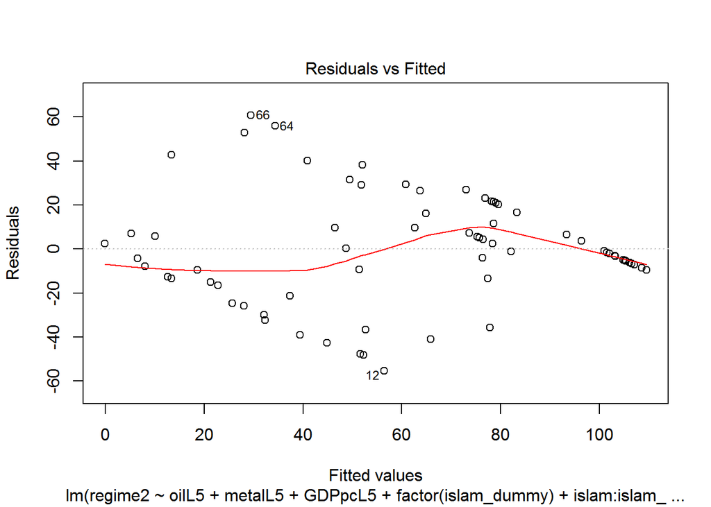

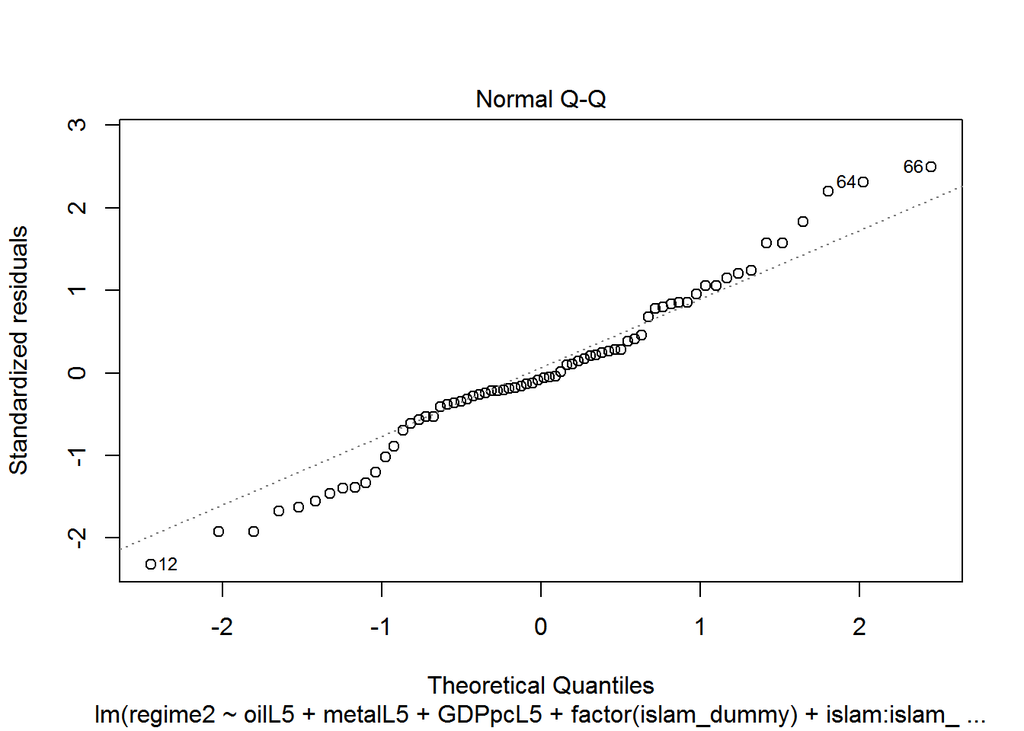

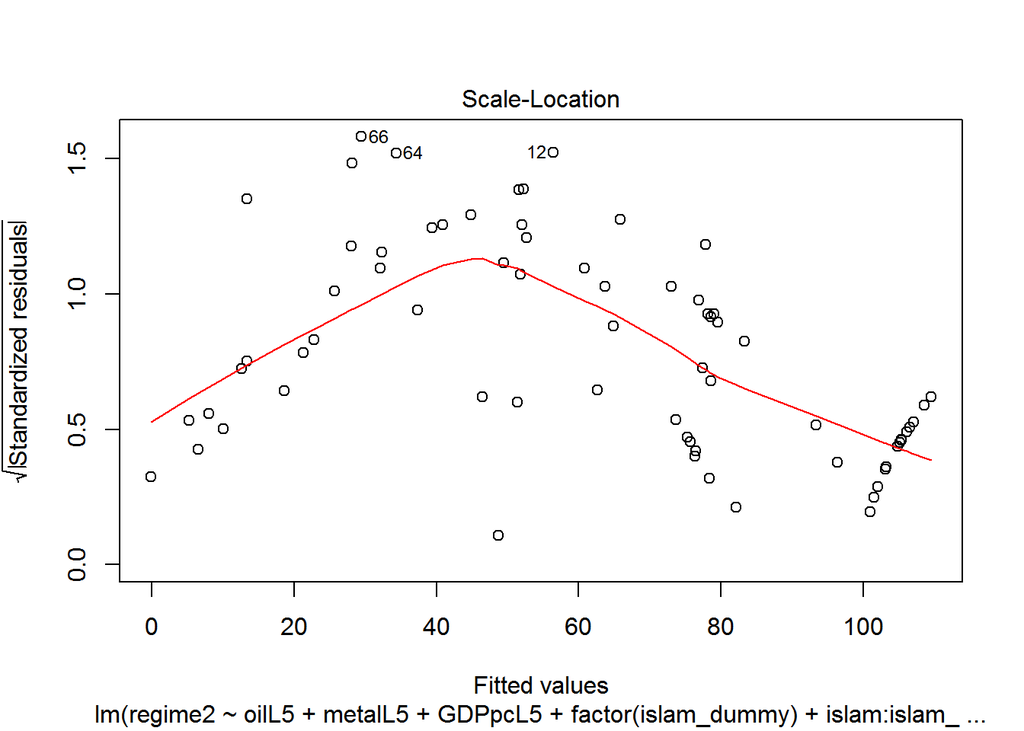

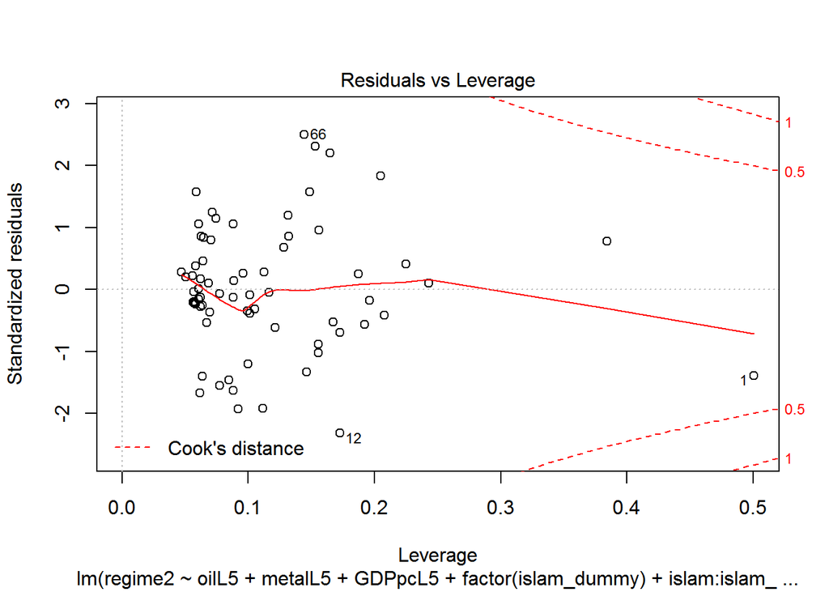

```r
plot(Model6)
```

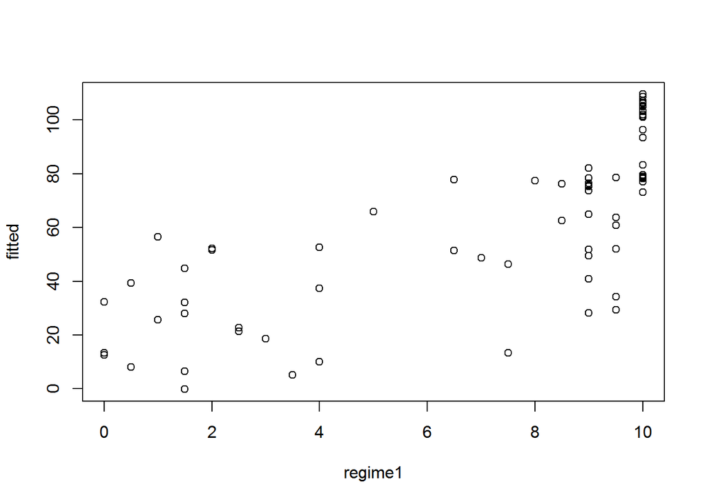

```r
results = data.frame(residuals = Model6$residuals, fitted = Model6$fitted.values, std.resids = rstandard(Model6), rossoil)
par(mfrow = c(1,1))
plot(fitted ~ regime1, results)
```

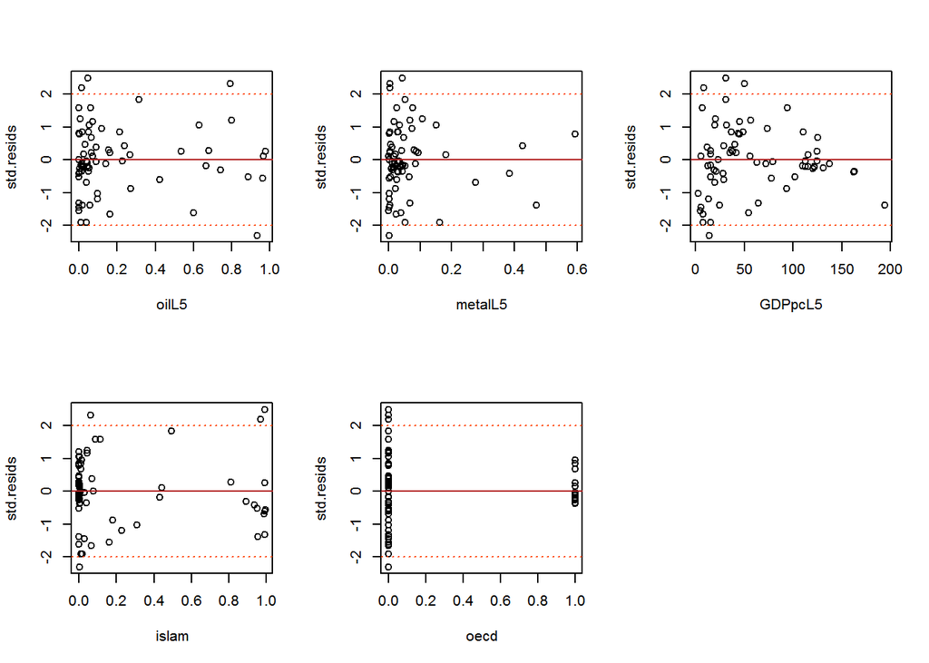

```r
par(mfrow = c(2,3))
plot(std.resids ~ oilL5, results)
abline(h = 2, lty = 3, col = 'orangered'); abline(h = -2, lty = 3, col = 'orangered'); abline(h = 0, lty = 1, col = 'firebrick')
plot(std.resids ~ metalL5, results)
abline(h = 2, lty = 3, col = 'orangered'); abline(h = -2, lty = 3, col = 'orangered'); abline(h = 0, lty = 1, col = 'firebrick')
plot(std.resids ~ GDPpcL5, results)
abline(h = 2, lty = 3, col = 'orangered'); abline(h = -2, lty = 3, col = 'orangered'); abline(h = 0, lty = 1, col = 'firebrick')
plot(std.resids ~ islam, results)
abline(h = 2, lty = 3, col = 'orangered'); abline(h = -2, lty = 3, col = 'orangered'); abline(h = 0, lty = 1, col = 'firebrick')
plot(std.resids ~ oecd, results)
abline(h = 2, lty = 3, col = 'orangered'); abline(h = -2, lty = 3, col = 'orangered'); abline(h = 0, lty = 1, col = 'firebrick')
```

# NOTES:

**I would like to know how to log transform ‘islam’ in such a way that it gets “turned on” in the equation when the ‘islam dummy’ = 1, but log(islam) is “turned off” when the ‘islam_dummy’ = 0. Would I just add the 0.001 to ‘islam’ when transforming the variable? Could you please help with this after the test is graded? Thank you!**